# 2024 School Characteristics

Janette Avelar

2024-04-30

```r
#manual branding - file won't load
transcend_cols = c("#1A4C81","#59C3B4","#EF464B","#ADE0EE")
transcend_cols2 = c("#BC2582","#FFA630","#FFDE42","#99C24D","#218380","#D3B7D7")
transcend_grays = c("#4D4D4F","#9D9FA2","#D1D3D4")
transcend_na = transcend_grays[2]
theme_transcend = theme_gdocs(base_size = 14, base_family = "Open Sans") +
  theme(
    plot.title = element_text(family = "Bebas Neue", color = "black"),
    plot.background = element_blank(),
    axis.text = element_text(colour = "black"),
    axis.title = element_text(colour = "black"),
    panel.border = element_rect(colour = "#4D4D4F"),
    strip.text = element_text(size = rel(0.8)),
    plot.margin = margin(10, 24, 10, 10, "pt")
  )
theme_set(theme_transcend)
```

```r
#barplot function
barplot <- function(x, data, metric, palette = transcend_cols, title = "Some title"){
  # Ensure metric is a character string
  if (!is.character(metric) || length(metric) != 1) {
    stop("Metric must be a single character string indicating 'n' or 'pct'.")
  }

  data <- data %>%
    mutate(rate = 1) %>%
    group_by({{x}}) %>%
    summarize(n = sum(rate)) %>%
    ungroup() %>%
    mutate(total = sum(n),
           pct = n/total) %>%
    filter(!is.na({{x}}))

  y_var <- ifelse(metric == "n", "n", "pct")
  y_lab <- ifelse(metric == "n", "Number of schools", "Percentage of schools")

  # Setup plot
  plot <- ggplot(data, aes(x = {{x}}, y = .data[[y_var]], fill = {{x}})) +
    geom_col() +
    scale_fill_manual(values = palette) +
    theme(legend.position = "none", panel.grid.major.x = element_blank()) +
    labs(title = title, x = "", y = y_lab)

  # Configure y-axis and labels based on metric
  if (metric == "n") {
    max_y <- max(data[[y_var]], na.rm = TRUE)
    limit_upper <- max_y * 1.1
    plot <- plot + scale_y_continuous(expand = c(0, 0), limits = c(0, limit_upper))
    plot <- plot + geom_text(aes(label = n), nudge_y = 0.5, vjust = 0, color = transcend_na, fontface = "bold", size = 5.5, family = "sans")
  } else if (metric == "pct") {
    plot <- plot + scale_y_continuous(expand = c(0, 0), limits = c(0, 1), labels = scales::percent_format())
    plot <- plot + geom_text(aes(label = scales::label_percent(accuracy = 1)(pct)), nudge_y = 0.01, vjust = 0, color = transcend_na, fontface = "bold", size = 5.5, family = "sans")
  }

  return(plot)
}
```

## Locale

Guiding question: **What’s the breakdown of schools in the data by locale (urban, suburban, rural)?**

As in prior years, the majority of our schools serve students in urban geographic regions (52%). Roughly 1 in 5 schools serve rural regions and mixed regions. Suburban schools just shy of 10% constitute the smallest group, a notable drop from previous years. It’s possible this could indicate our new labels “multiple” for mixed regions better describes their student populations than “suburban” alone.

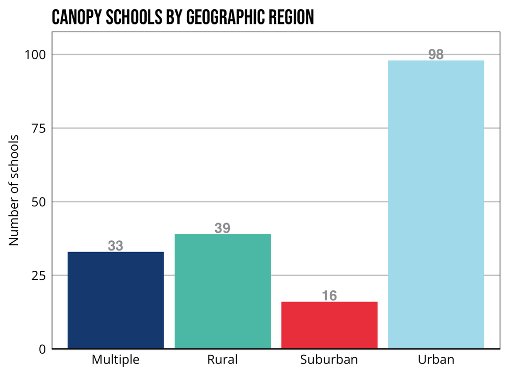

```r
barplot(school_locale, variables, 'n', transcend_cols, "Canopy schools by geographic region")
```

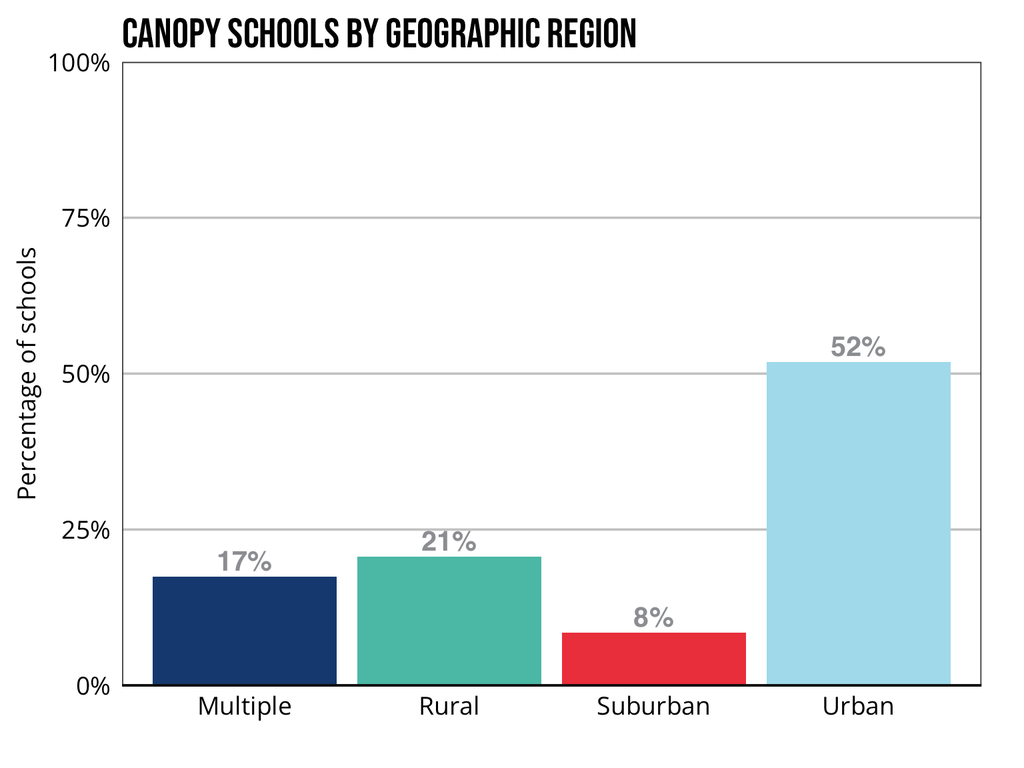

```r
barplot(school_locale, variables, 'pct', transcend_cols, "Canopy schools by geographic region")
```

## Level

Guiding question: **What’s the breakdown of schools in the data by level (elementary, middle, high)?**

*Note*: We allow schools to fall into more than one category (PK, elementary, middle, high), thus the proportions do not add up to 100%.

The majority of Canopy schools are high schools (68%). Nearly half of Canopy schools are an elementary (43%) or middle school (47%). PreK continues to be underrepresented, though 1 in 5 schools offer prekindergarten either as a standalone early childhood education school or as part of their K+ programming.

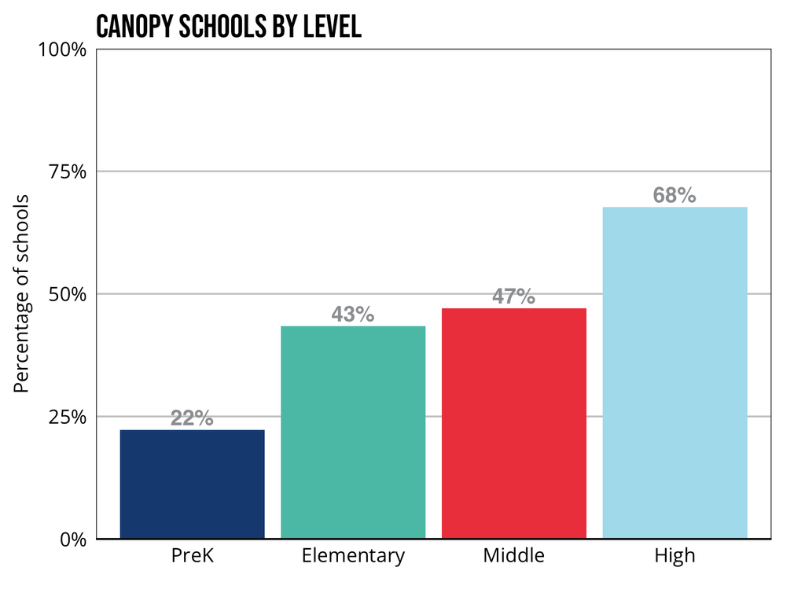

```r
full %>%
  pivot_longer(cols = c("grades_pk", "grades_elementary", "grades_middle", "grades_high"),
               names_to = "school_level",
               values_to = "school_level_value",
               names_prefix = "grades_") %>%
  filter(school_level_value == 1) %>%
  group_by(school_level) %>%
  summarize(n = sum(school_level_value),
            pct = n/189) %>%
  mutate(school_level = factor(school_level, levels = c("pk", "elementary", "middle", "high"), labels = c("PreK", "Elementary", "Middle", "High"))) %>%
  ggplot(., aes(school_level, y = pct, fill = school_level)) +
    geom_col() +
    scale_fill_manual(values = transcend_cols) +
    theme(legend.position = "none", panel.grid.major.x = element_blank()) +
    labs(title = "Canopy schools by level", x = "", y = "Percentage of schools") +
    scale_y_continuous(expand = c(0, 0), limits = c(0, 1), labels = scales::percent_format()) +
    geom_text(aes(label = scales::label_percent(accuracy = 1)(pct)), nudge_y = 0.01, vjust = 0, color = transcend_na, fontface = "bold", size = 5.5, family = "sans")
```

## Type

Guiding question: **What’s the breakdown of schools in the data by school type (charter, district, independent)?**  
As in prior years, district and charter schools make up the majority of Canopy schools. They each comprise roughly 40% of all 2024 schools. The remaining fifth are independent, or private, schools.

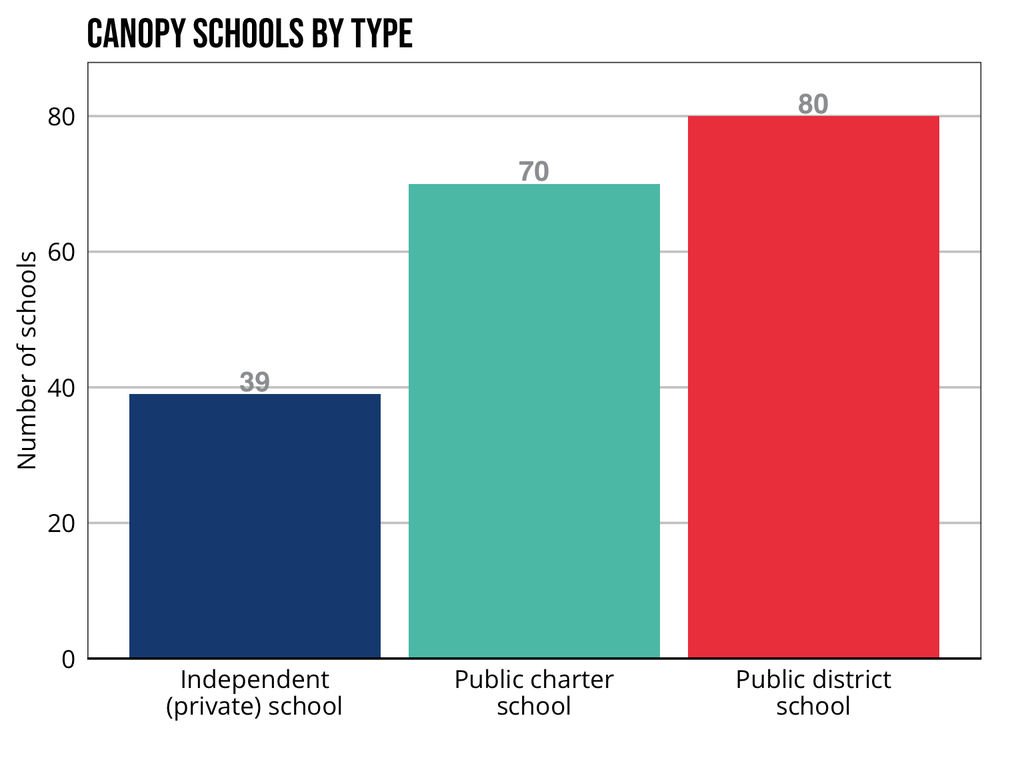

```r
barplot(school_type, variables, 'n', transcend_cols, "Canopy schools by type") +
  scale_x_discrete(labels = wrap_format(20))
```

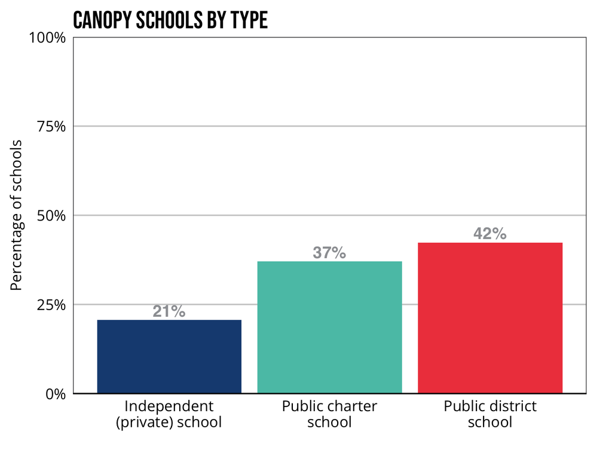

```r
barplot(school_type, variables, 'pct', transcend_cols, "Canopy schools by type") +
  scale_x_discrete(labels = wrap_format(20))
```

## Descriptor

Guiding question: **What’s the breakdown of schools by descriptor?**

Along with reporting grades offered, geographic regions served, and governance model, we ask Canopy schools to provide any additional descriptors that describe their work. A fifth of Canopy schools identified as microschools or school-within-schools. Only 2% identified as homeschools.

*Note:* These percentages only reflect the number of Canopy schools that fall into a single category. Schools were able to select as many descriptors as they wanted, thus they may fall into multiple categories at one time.

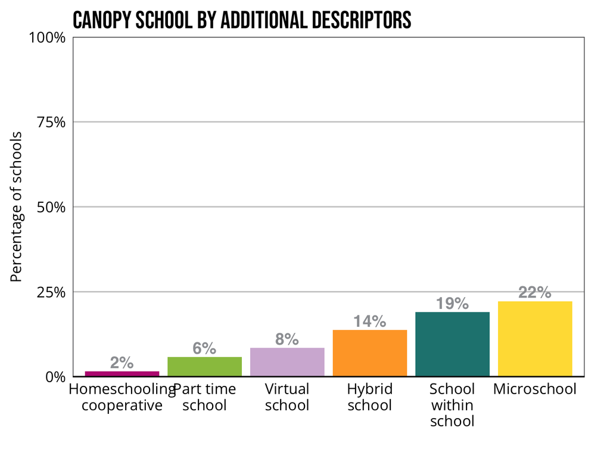

```r
variables %>%
  pivot_longer(cols = starts_with("school_desc") & !matches("school_desc_other_text"),
               names_to = "school_descriptor",
               values_to = "school_descriptor_value",
               names_prefix = "school_desc_") %>%
  filter(school_descriptor_value == 1) %>%
  group_by(school_descriptor) %>%
  summarize(n = sum(school_descriptor_value),
            pct = n/189) %>%
  filter(school_descriptor != "other") %>%
  mutate(school_descriptor = case_when(
    school_descriptor == "homeschool" ~ "Homeschooling cooperative",
    school_descriptor == "part_time" ~ "Part time school",
    school_descriptor == "virtual" ~ "Virtual school",
    school_descriptor == "hybrid" ~ "Hybrid school",
    school_descriptor == "sws" ~ "School within school",
    school_descriptor == "micro" ~ "Microschool"
  )) %>%
  ggplot(., aes(reorder(school_descriptor, pct), y = pct, fill = school_descriptor)) +
    geom_col() +
    scale_fill_manual(values = transcend_cols2) +
    theme(legend.position = "none", panel.grid.major.x = element_blank()) +
    labs(title = "Canopy school by additional descriptors", x = "", y = "Percentage of schools") +
    scale_y_continuous(expand = c(0, 0), limits = c(0, 1), labels = scales::percent_format()) +
    geom_text(aes(label = scales::label_percent(accuracy = 1)(pct)), nudge_y = 0.01, vjust = 0, color = transcend_na, fontface = "bold", size = 5.5, family = "sans") +
  scale_x_discrete(labels = wrap_format(12))
```

Additional digging into microschools: **Why are microschools such a large proportion of our sample? Which schools are identifying as microschools?**

```r
variables %>%
  filter(school_desc_micro == 1) %>%
  select(school_id, school_name, school_state, school_type, school_locale, school_enrollment, grades_pk, grades_elementary, grades_middle, grades_high) %>%
  datatable()
```

|  | school_id | school_name | school_state | school_type | school_locale | school_enrollment | grades_pk | grades_elementary | grades_middle | grades_high |
| --- | --- | --- | --- | --- | --- | --- | --- | --- | --- | --- |
| 1 | 8 | Anastasis Academy | Colorado | Independent (private) school | Suburban | 54 | 0 | 1 | 1 | 0 |
| 2 | 71 | Fannie Lou Hamer Freedom High School | New York | Public district school | Urban | 460 | 0 | 0 | 0 | 1 |
| 3 | 98 | Howard Middle School for Math and Science | District of Columbia | Public charter school | Urban | 288 | 0 | 0 | 1 | 0 |
| 4 | 105 | Juab High School | Utah | Public district school | Rural | 874 | 0 | 0 | 0 | 1 |
| 5 | 141 | Norris Academy | Wisconsin | Public district school | Rural | 80 | 0 | 1 | 1 | 1 |
| 6 | 150 | Lab51 | Idaho | Independent (private) school | Multiple | 92 | 0 | 0 | 0 | 1 |
| 7 | 247 | Blue Valley Center for Advanced Professional Studies (CAPS) | Kansas | Public district school | Suburban | 900 | 0 | 0 | 0 | 1 |
| 8 | 256 | Da Vinci RISE High | California | Public charter school | Urban | 187 | 0 | 0 | 0 | 1 |
| 9 | 266 | Embark Education | Colorado | Independent (private) school | Urban | 32 | 0 | 0 | 1 | 0 |
| 10 | 312 | Nashville Big Picture High School | Tennessee | Public district school | Urban | 145 | 0 | 0 | 0 | 1 |

[output cut: 32 more lines]

Additional digging into school-within-schools: **What are school-within-schools such a large proportion of our sample? Which schools are identifying as schools-within-schools?**

```r
variables %>%
  filter(school_desc_sws == 1) %>%
  select(school_id, school_name, school_state, school_type, school_locale, school_enrollment, grades_pk, grades_elementary, grades_middle, grades_high) %>%
  datatable()
```

|  | school_id | school_name | school_state | school_type | school_locale | school_enrollment | grades_pk | grades_elementary | grades_middle | grades_high |
| --- | --- | --- | --- | --- | --- | --- | --- | --- | --- | --- |
| 1 | 10 | Asa Messer Elementary School | Rhode Island | Public district school | Urban | 545 | 1 | 1 | 0 | 0 |
| 2 | 35 | CICS West Belden | Illinois | Public charter school | Urban | 531 | 0 | 1 | 1 | 0 |
| 3 | 47 | Concourse Village Elementary School | New York | Public district school | Urban | 176 | 1 | 1 | 0 | 0 |
| 4 | 52 | DB EXCEL (Kingsport) | Tennessee | Public district school | Suburban | 250 | 0 | 0 | 0 | 1 |
| 5 | 76 | Flushing International High School | New York | Public district school | Urban | 423 | 0 | 0 | 0 | 1 |
| 6 | 85 | Girls Athletic Leadership Middle School | Colorado | Public charter school | Urban | 197 | 0 | 0 | 1 | 0 |
| 7 | 105 | Juab High School | Utah | Public district school | Rural | 874 | 0 | 0 | 0 | 1 |
| 8 | 140 | Noble High School | Maine | Public district school | Rural | 1197 | 0 | 0 | 0 | 1 |
| 9 | 184 | Siloam Springs High School Conversion Charter | Arkansas | Public charter school | Rural | 1370 | 0 | 0 | 0 | 1 |
| 10 | 235 | International School of the Americas | Texas | Public district school | Urban | 486 | 0 | 0 | 0 | 1 |

[output cut: 26 more lines]

Guiding question: **What’s the average number of enrolled students in these schools?**

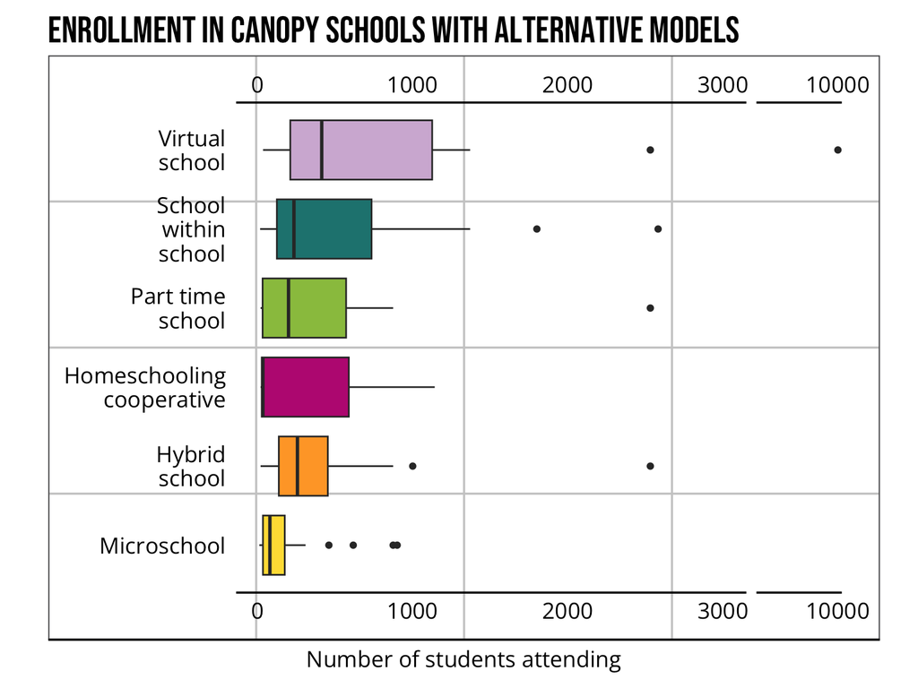

```r
variables %>%
  pivot_longer(cols = starts_with("school_desc") & !matches("school_desc_other_text"),
               names_to = "school_descriptor",
               values_to = "school_descriptor_value",
               names_prefix = "school_desc_") %>%
  filter(school_descriptor_value == 1) %>%
  filter(school_descriptor != "other") %>%
  mutate(school_descriptor = case_when(
    school_descriptor == "homeschool" ~ "Homeschooling cooperative",
    school_descriptor == "part_time" ~ "Part time school",
    school_descriptor == "virtual" ~ "Virtual school",
    school_descriptor == "hybrid" ~ "Hybrid school",
    school_descriptor == "sws" ~ "School within school",
    school_descriptor == "micro" ~ "Microschool"
  )) %>%
  ggplot(., aes(reorder(school_descriptor, school_enrollment), school_enrollment, fill = school_descriptor)) +
    geom_boxplot() +
    scale_fill_manual(values = transcend_cols2) +
    theme(legend.position = "none",
          panel.grid.major = element_blank(),
          panel.grid.minor = element_blank(),
          panel.border = element_blank()) +
    labs(title = "Enrollment in Canopy schools with alternative models", x = "", y = "Number of students attending") +
  scale_x_discrete(labels = wrap_format(12)) +
  coord_flip() +
  scale_y_break(c(3000, 9500), expand = TRUE) +
  scale_y_continuous(
        breaks = c(seq(0, 3000, 1000), 10000),
        labels = c(seq(0, 3000, 1000), "10000")) +
  theme(axis.text.y.right = element_blank(),
        axis.line.y.right = element_blank(),
        axis.ticks.y.right = element_blank(),
        panel.grid.minor = element_blank())
```

## Demographics

### Leadership

Guiding question: **What’s the racial/ethnic breakdown of Canopy school leadership teams?**

Nearly half of Canopy schools have a majority-BIPOC leadership team with 50% or more of leaders identifying as people of color. 40% of schools have a majority-White leadership team with less than 24% of leaders identifying as a person of color.

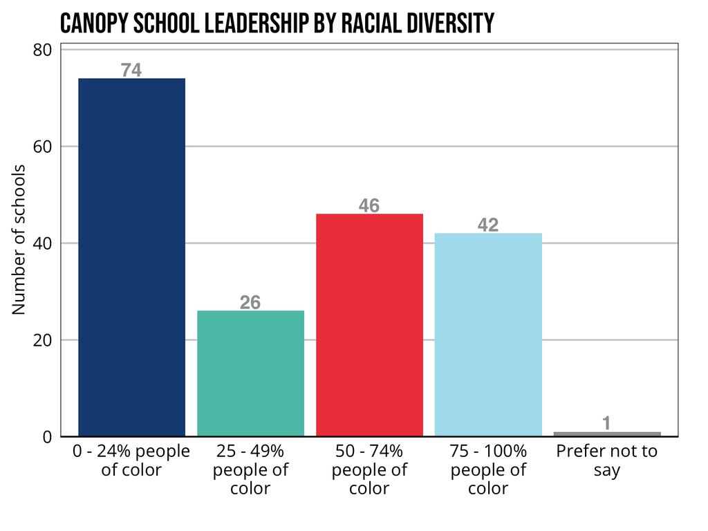

```r
barplot(leadership_diversity, variables, 'n', c(transcend_cols, transcend_grays[2]), "Canopy school leadership by racial diversity") +
  scale_x_discrete(labels = wrap_format(15))
```

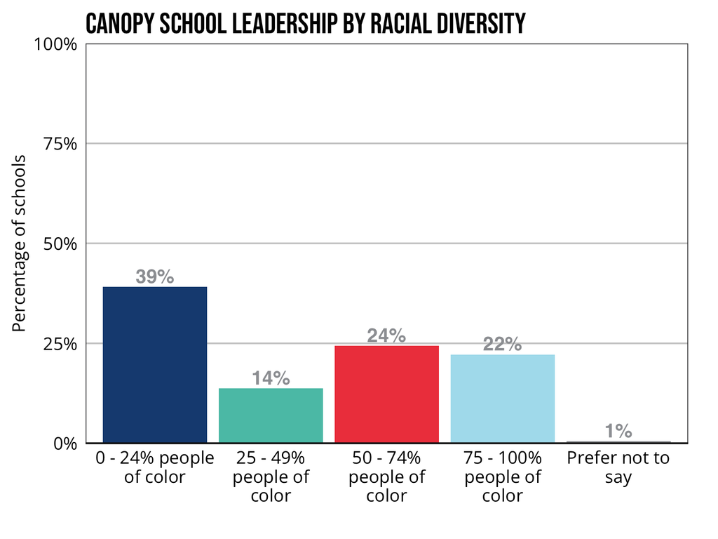

```r
barplot(leadership_diversity, variables, 'pct', c(transcend_cols, transcend_grays[2]), "Canopy school leadership by racial diversity") +
  scale_x_discrete(labels = wrap_format(15))
```

## Region

Guiding question: **Which states are represented or not?**

There are 40 states (including D.C.) represented in our 2024 sample, with the top 5 states representing California (N = 19), Massachusetts (N = 12), Arizona (N = 10), Colorado (N = 10), and New York (N = 10). The table and figure below display the distribution of schools across states.

The states not represented are:  
- Alaska  
- Delaware  
- Kentucky  
- Maryland  
- Mississippi  
- Montana  
- Nevada  
- New Jersey  
- Oklahoma  
- West Virginia  
- Wyoming

```r
#table
states <- variables %>%
  select(school_id, school_state) %>%
  mutate(rate = 1) %>%
  select(!school_id) %>%
  group_by(school_state) %>%
  summarize(N = sum(rate)) %>%
  mutate(school_state = case_when(school_state == "" ~ "Unknown",
                                TRUE ~ as.character(school_state))) %>%
  rename(`State` = school_state)
datatable(states)
```

|  | State | N |
| --- | --- | --- |
| 1 | Alabama | 2 |
| 2 | Arizona | 10 |
| 3 | Arkansas | 4 |
| 4 | California | 19 |
| 5 | Colorado | 10 |
| 6 | Connecticut | 2 |
| 7 | District of Columbia | 3 |
| 8 | Florida | 4 |
| 9 | Georgia | 2 |
| 10 | Hawaii | 3 |

[output cut: 30 more lines]

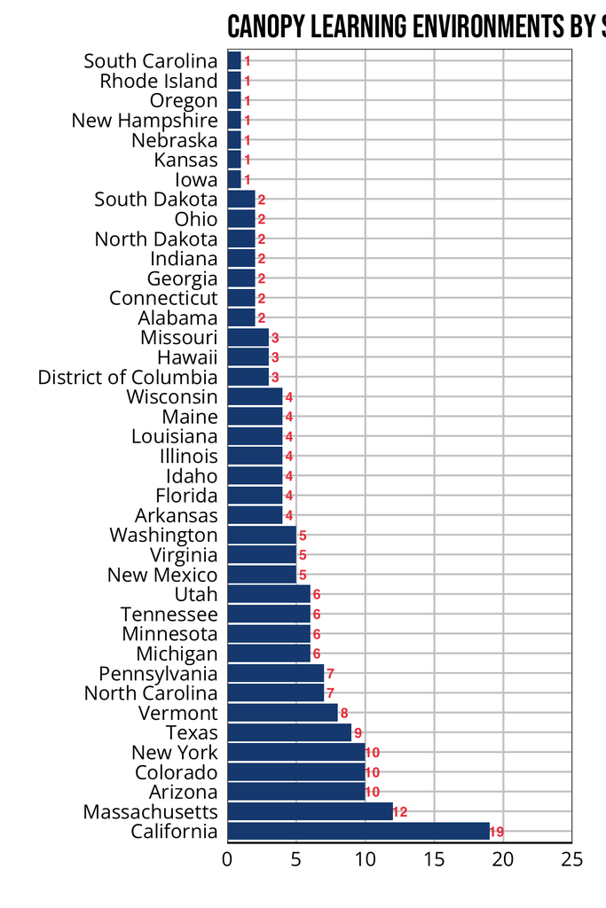

```r
#viz
states %>%
  filter(!is.na(State)) %>%
ggplot(., aes(reorder(State, -N), N)) +
  geom_col(fill = transcend_cols[1]) +
  scale_y_continuous(limits=c(0, 25), expand = c(0,0)) +
  coord_flip() +
  labs(title = "Canopy Learning Environments by State",
       x = "",
       y = "") +
  geom_text(aes(label = signif(N)),
            nudge_y = .5,
            color = transcend_cols[3],
            fontface = "bold",
            size = 3.5,
            family = "sans")
```

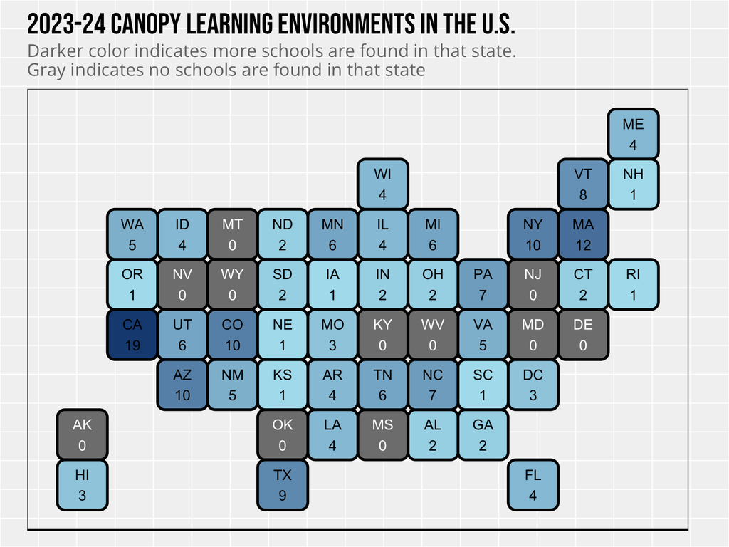

```r
#abbreviations list
st_crosswalk <- tibble(state = state.name) %>%
   bind_cols(tibble(abb = state.abb)) %>%
   bind_rows(tibble(state = "District of Columbia", abb = "DC")) %>%
  rename(State = state)
#missing state list
na_state <- data.frame("State" = c("Alaska","Delaware","Kentucky","Maryland","Mississippi","Montana","Nevada","New Jersey","Oklahoma","West Virginia","Wyoming"),
                          "N" = rep(NA, 11)) %>%
  #merge missing state with data
  bind_rows(states) %>%
  mutate(color = case_when(
    is.na(N) ~ paste0(transcend_cols[3]),
    TRUE ~ paste0(transcend_cols[1])
  )) %>% #ignore color col for now
  left_join(st_crosswalk, by = "State") %>%
  group_by(State) %>%
  mutate(label = paste0({abb},"\n",{N}),
         label = case_when(
           is.na(N) ~ paste0({abb},"\n0"),
           TRUE ~ as.character(label)
         ))
#build plot
state_bins <-
statebins(state_data = na_state,
          font_size = 4,
          state_border_col = "black",
          state_border_size = 1,
          state_col = "State",
          value_col = "N",
          labels = "label",
          round = TRUE,
          light_label = "black",
          dark_label = "black") +
  theme_transcend +
  scale_fill_gradient(low = transcend_cols[4],
                       high = transcend_cols[1]) +
  labs(title = "2023-24 Canopy Learning Environments in the U.S.",
       subtitle = "Darker color indicates more schools are found in that state.\nGray indicates no schools are found in that state") +
  theme(legend.position = "none",
        axis.title = element_blank(),
        axis.text  = element_blank(),
        axis.ticks = element_blank(),
        panel.background = element_blank(),
        panel.grid.major = element_blank(),
        panel.grid.minor = element_blank(),
        plot.background = element_blank())
sb = ggplot_build(state_bins)
sb$data[[2]]$label = na_state$label[match(sb$data[[2]]$label, na_state$abb)]
sb = ggplot_gtable(sb)
plot_states <- plot(sb)
```

```r
png(filename = here("output", "state-bins_V1.png"),
    width = 12, height = 8, units = "in", res = 300)
dev.off()
```